# FoRAGE Fitting-2

TaniaBarychka

26 February 2020

This is to carry on fitting FoRAGE database, in particular dealing with poor fit of handling times.

```
##
##                     Amphibian       Arachnid           Bird    Chrysophyte
##              2             13            308             25              4
##        Ciliate      Cnidarian     Crustacean     Ctenophore Dinoflagellate
##             42             37            383             26             40
##       Euglenid           Fish         Insect         Mammal        Mollusk
##              2            399            712             30             10
##  Platyhelminth        Reptile        Rotifer      Sarcodine     Tardigrade
##              6              3             33              3              5
```

```
##
##                Angiosperm Invertebrate    Protozoan   Vertebrate
##            0            0         1520           91          470
```

One of the commonest reasons for a lack of fit is through the existence of outliers in the data. It is important to understand howevre, that a point way *appear* to be an outlier becasue of teh **misspecification of the model**, and not because there is anything wrong with the data.

**It is important to understand that analysis of residuals is a very poor way of looking for influence**. Precisely because a point is highl;y influential, it **forces the regression line close to it, and hence the influential point may have very small residual.**

- log-prey bodymass
- log-predator bodymass
- log-temperature

**As a function of Prey bodymass** https://rpubs.com/RatherBit/188960

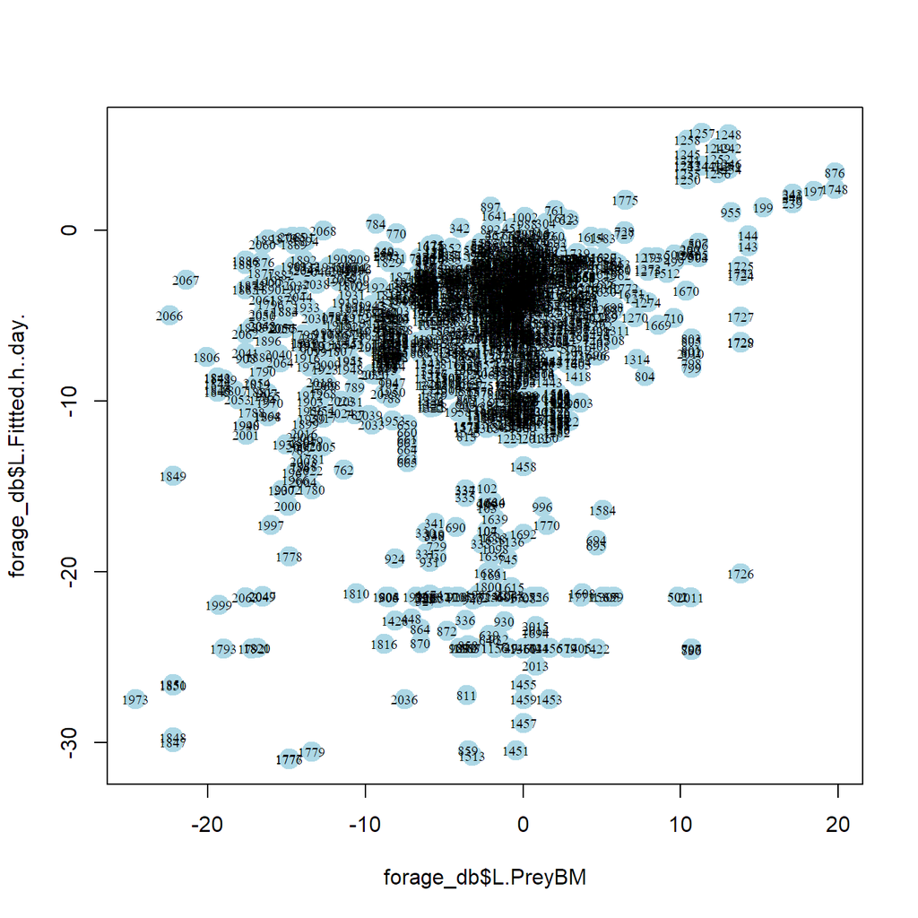

```r
#prey
plot(forage_db$L.Fittted.h..day.~forage_db$L.PreyBM, col="lightblue", pch=19, cex=2)

### this add the labels to the points using their rownames
### font = 2 is bold

text(forage_db$L.Fittted.h..day.~forage_db$L.PreyBM, labels=rownames(forage_db),data=forage_db, cex=0.6, font=5)
```

```r
modPrey<-lm(forage_db$L.Fittted.h..day.~forage_db$L.PreyBM)
summary(modPrey)
```

```
##
## Call:
## lm(formula = forage_db$L.Fittted.h..day. ~ forage_db$L.PreyBM)
##
## Residuals:
##     Min      1Q  Median      3Q     Max
## -24.607  -1.395   1.668   3.311   9.042
##
## Coefficients:
##                    Estimate Std. Error t value Pr(>|t|)
## (Intercept)        -5.71595    0.14215 -40.209   <2e-16 ***
## forage_db$L.PreyBM  0.21382    0.02192   9.756   <2e-16 ***
## ---
## Signif. codes:  0 '***' 0.001 '**' 0.01 '*' 0.05 '.' 0.1 ' ' 1
##
## Residual standard error: 5.527 on 1781 degrees of freedom
##   (298 observations deleted due to missingness)
## Multiple R-squared:  0.05073,    Adjusted R-squared:  0.0502
## F-statistic: 95.18 on 1 and 1781 DF,  p-value: < 2.2e-16
```

I look at the most extreme values of the explanatory variable (Prey Body mass) both to the left (extreme low values) and the right (extreme high values), as judged by (x-xmean)^2:

[output not shown]

```r
#outliers with car function
outlierTest(modPrey)
```

```
##       rstudent unadjusted p-value Bonferroni p
## 1449 -4.477157         8.0443e-06     0.014343
## 1511 -4.429553         1.0017e-05     0.017861
## 859  -4.357545         1.3903e-05     0.024790
```

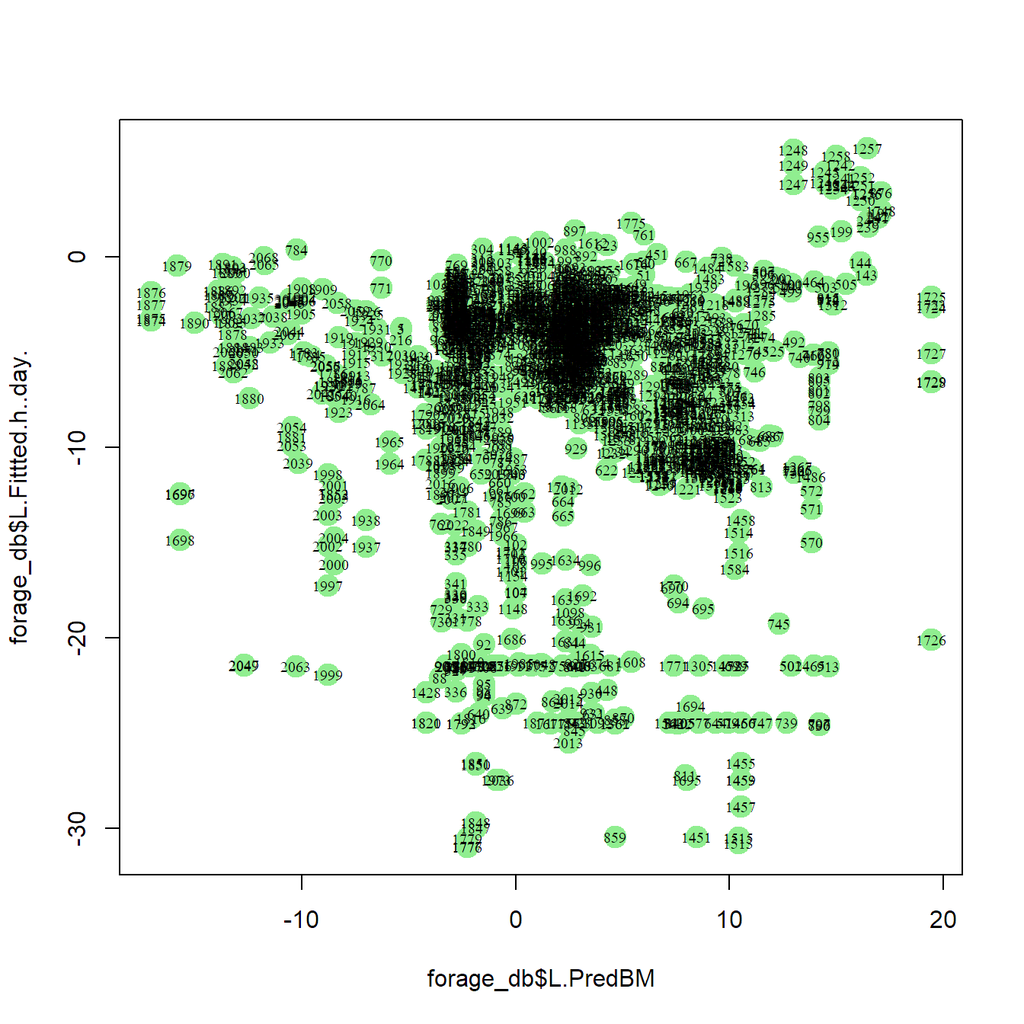

```r
#predator
plot(forage_db$L.Fittted.h..day.~forage_db$L.PredBM, col="lightgreen", pch=19, cex=2)

### this add the labels to the points using their rownames
### font = 2 is bold

text(forage_db$L.Fittted.h..day.~forage_db$L.PredBM, labels=rownames(forage_db),data=forage_db, cex=0.6, font=5)
```

Ideally, they are the same points.

If they belong to the same group (e.g. freshwater) then I’ll remove the points and re-fit to the group.

If they don’t belong to the same group, I’ll remove and refit.

The cook’s distance for each observation i measures the change in Y^ (fitted Y) for all observations with and without the presence of observation i, so we know how much the observation i impacted the fitted values. In general use, those observations that have a cook’s distance greater than 4 times the mean may be classified as influential. This is not a hard boundary.

In full model: http://r-statistics.co/Outlier-Treatment-With-R.html

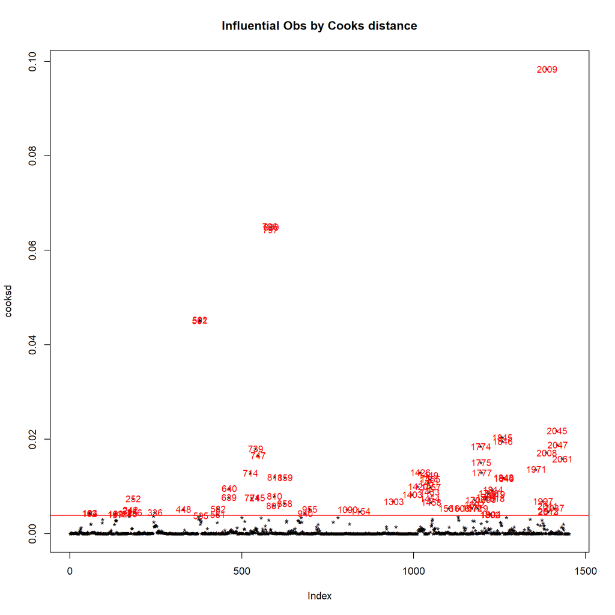

```
##       L.PredBM  L.PreyBM L.Fittted.h..day.    temp_A   VertInvert EctoEndo
## 102  0.0295588 -2.273026        -15.049943 -2.285384 Invertebrate     Ecto
## 103  0.0295588 -2.273026        -16.230145 -1.985384 Invertebrate     Ecto
## 104  0.0295588 -2.273026        -17.557791 -1.689652 Invertebrate     Ecto
## 197 17.0964218 18.430631          2.332144  2.169857   Vertebrate     Endo
## 199 15.2337880 15.245822          1.363537  2.169857   Vertebrate     Endo
## 240 16.4896592 17.085079          1.931521  2.169857   Vertebrate     Endo
```

We get 79 influential values **based on the model that includes prey, predator and arrhenius temp.**

The function outlierTest from car package gives the most extreme observation based on the given model. Here’s an example based on the mod linear model object we’d just created.

The outliers package provides a number of useful functions to systematically extract outliers.

```
##       rstudent unadjusted p-value Bonferroni p
## 2009 -5.297746         1.3542e-07   0.00019662
## 859  -4.829260         1.5161e-06   0.00220140
## 2011 -4.486360         7.8194e-06   0.01135400
## 1719 -4.226114         2.5267e-05   0.03668700
## 1449 -4.200506         2.8262e-05   0.04103700
```

```
## [1] -17.07261
```

```
##   [1]   1   2   3   4   5   6   7   8   9  10  11  12  13  14  15  16  17
##  [18]  18  19  20  21  22  23  24  25  26  27  28  29  30  31  32  33  34
##  [35]  35  36  37  38  39  40  41  42  43  44  45  46  47  48  49  50  51
##  [52]  52  53  54  55  56  57  58  59  60  61  62  63  64  65  66  67  68
##  [69]  69  70  71  72  73  74  75  76  77  78  79  80  81  82  83  84  85
##  [86]  86  87  88  89  90  91  92  93  94  95  96  97  98  99 100 101 102
## [103] 103 104 105 106 107 108 109 110 111 112 113 114 115 116 117 118 119
## [120] 120 121 122 123 124 125 126 127 128 129 130 131 132 133 134 135 136
## [137] 137 138 139 140 141 142 143 144 145 146 147 148 149 150 151 152 153
## [154] 154 155 156 157 158 159
```

I would like to see whether values identified as influential based on the model(s) form part of a group in the database.

I should also look at other models: Ht~Prey Bodymass; HT~PreyBody mass.

```
##
##                     Amphibian       Arachnid           Bird    Chrysophyte
##              0              0              3              6              0
##        Ciliate      Cnidarian     Crustacean     Ctenophore Dinoflagellate
##              2              6             20              3              2
##       Euglenid           Fish         Insect         Mammal        Mollusk
##              0             13             15              8              0
##  Platyhelminth        Reptile        Rotifer      Sarcodine     Tardigrade
##              0              0              1              0              0
```